# Data Camp Project

## App store application success

[figure not shown]

Authors :

- NOUMEDEM DJIEUZEM Boris DIlane
- NJIFENJOU Ahmed Ndouop
- ROUX Charles
- FARES Saif
- TAFFET Alexandre

## Table of content

```python
from jyquickhelper import add_notebook_menu
add_notebook_menu()
```

run previous cell, wait for 2 seconds

## Import

```python
#File manipulation  and date
import os
import glob
import requests
from PIL import Image
from io import BytesIO
import random
from datetime import datetime

# Data Processing
import numpy as np
import pandas as pd

# Basic Visualization tools
import matplotlib.pyplot as plt
plt.style.use('ggplot')
import seaborn as sns
sns.set_palette('husl')
cmap_cust = sns.color_palette("husl", n_colors = 2)
from IPython.display import Markdown
def bold(string):
    display(Markdown("**"+string+"**"))


# Bokeh (interactive visualization)
from bokeh.io import show, output_notebook
from bokeh.palettes import Spectral9
from bokeh.plotting import figure
output_notebook()
```

```python
import sys
import warnings

if not sys.warnoptions:
    warnings.simplefilter("ignore")
```

```python
# Verification of the working repository
os.getcwd()
```

## Introduction

### Project interest

Nowadays, mobile applications are part of our daily lives. They now account for more than half (52%) of the time spent on digital media on the one hand, and would account for 89% of the time spent by users of on their smartphone.Thereby, it is not surprising that since 2016, the market for mobile applications has experienced unprecedented growth. It is now worth billions of dollars, through the marketing of mobile games in particular, and it explains the attractivity of this market for developers and investors.

[figure not shown]

Number of available apps in the Apple App Store from 2008 to 2020 (Source : Statista)

In reality, the market for applications is rather centralised, especially on platforms such as the App Store or the Play Store. These sites contain a lot of information about applications, and it would be useful to exploit them. For instance, it would be interesting to develop a decision-making tool, particularly for developers, to better understand market expectations and predict whether a certain type of application will potentially be more successful than another. Also, such a tool could be quite useful for investors, or for the previously cited app stores, which could improve their recommandation systems.

Bearing this in mind, one can wonder whether it is possible to **predict the success of an app on the app store from the information available about this application**.

We will focus on mobile games, since they represent a large share of the mobile application market.

### Performance indicator

First of all, we need to define the notion of succes of an application. There are two obvious ways of defining this success:

1. The average rating given to the application
2. The number of downloads

[figure not shown]

For our study, we should really take into account both criterions. Indeed, if we only focus on ratings, an app with a rating of 5 stars and which was downloaded only 20 times would have a higher "success" than another one with 4 stars but 20 000 downloads. On the other hand, by only considering the downloads, an app with a rating of 3 and 1000 downloads would be more successful than the one with a rating of 4 and 500 downloads. It is true that for an investor, the success would be mostly linked to the number of downloads. For a developer, the satisfaction of the users may be his top priority. What we want to show here is that coming up with a "fully objective" criterion to measure the success of an application is not an easy task, and is mostly subjective.

In order to satisfy both worlds, **we will define arbitrarily success as the total rating received by the application, averaged over its age**. To make things clear, we have:

$$ Success_{total} = Average Rating \times NbRatings $$

Such a criterion would most likely penalize the newest applications compared to the oldest ones, so we need to take into account the "age" of the app:

$$ Success = \frac{Average Rating \times NbRatings}{Age} $$

with the age for instance in months.

One remark is that we actually do not use the number of downloads in our "succes score". This is due tot he fact that the number of downloads is not available in the database, that we will present in the next section. But still, we can assume that there is a high correlation between the number of downloads and the number of ratings, so the later feature partially compensates for the absence of the other.

### Origin of the database

The data that will be used in this project are obtained by scraping on the Apple Store, particularly games applications which have a lot of user feedback.

The scraping we did was made possible thanks to APIs made available by Apple. We have in particular used [App Store Sitemap](https://itunes.apple.com/us/genre/id6014) to retrieve the "id" of applications.These are used in [iTunes Search API](https://affiliate.itunes.apple.com/resources/documentation/itunes-store-web-service-search-api/) to retrieve details about the applications that make up the main features of our database.

#### Description of the scraping:

- Collecting application's URLs

The App Store is organized by category, here we took the Games category. In each category, the applications are listed by letter and there is the possibility to have several pages for each letter.

So at first it was important to know what was the number of pages per letter in order to be able to retrieve the "id" of the corresponding applications. Also we used this to limit the number of pages per letter from which scraped the features (we took 70% of the pages per letter). To achieve this, we created intermediate functions to, among other things, generate the URL of a page from the associated letter and its page number.

- Scraping of application items:

First we observed the different items available for each application. Then we chose the features that could help us best answer to our problem of determining the success of an application. We used three of these features to calculate what would be a success and removed them from our covariates to avoid biasing the learning of success.

### Definition of the problem

- Aim: Predict the success (as defined above) of an *application*. This output is in $\mathbb{R}$
- Scoring: As we have a continuous output, what comes in hand is the Mean square error defined as follows: $$MSE = {\frac{1}{n} \sum_{i=1}^{n}(y_i-\hat{y}_i)^2} $$ We also compute the RMSE wich is define as $\sqrt{MSE} $ it can be compared with the typical value of the output. And then we consider a normalize RSME by dividing the RSME by the standard deviation of the output.

Here we use a Random Forest to predict the output $\hat{y}$ but any efficient strategy to predict a continuous output could be conceivable.

## Data Exploration

**Important to load data** As the database is somehow heavy to be uploaded on GitHub, we have implemented a script *./data/download_data.py* which downloads it from a google drive repository. This script is **compulsory** to be executed in order to load the data on your local environnement.

### Load Data

We start by loading the scrapped dataset in which the success indicator has been created according to the above description with the code appended to this starting kid.

```python
# Load dataset
data = pd.read_json('data/train.json')
#Test of existence of duplicates in the database
print('The database contains {} duplicates'.format(data.shape[0]-data.id_app.nunique()))
print('Nb unique = {}'.format(data.id_app.nunique()))
```

```
The database contains 0 duplicates
Nb unique = 77108
```

```python
data.head(3)
```

|  | id_app | releaseDate | artworkUrl512 | languageCodesISO2A | fileSizeBytes | minimumOsVersion | trackName | contentAdvisoryRating | genres | sellerName | formattedPrice | price | currency | version | description | currentVersionReleaseDate | age_app | success |
| --- | --- | --- | --- | --- | --- | --- | --- | --- | --- | --- | --- | --- | --- | --- | --- | --- | --- | --- |
| 86208 | 1198939406 | 2017-02-24T17:02:13Z | https://is2-ssl.mzstatic.com/image/thumb/Purpl... | [EN] | 134074368 | 7.0 | Tourist Transport Ship - Cruise Boat Simulator | 4+ | [Games, Entertainment, Simulation, Role Playing] | Khurram Fazal | Free | 0 | USD | 1.0 | Tourist Transport Ship is an ultimate game com... | 2017-02-24T17:02:13Z | 33.50 | 0.80597 |
| 76485 | 1156437682 | 2016-09-25T23:24:29Z | https://is3-ssl.mzstatic.com/image/thumb/Purpl... | [EN] | 171233280 | 6.0 | Soccer Championship Trophy - World Tour 3D | 4+ | [Games, Sports, Casual] | Tim umlas | Free | 0 | USD | 1.1 | Soccer Championship Trophy - World Tour 3D is ... | 2016-11-22T19:00:37Z | 38.50 | 0.00000 |
| 29308 | 527098535 | 2012-06-12T07:00:00Z | https://is3-ssl.mzstatic.com/image/thumb/Purpl... | [EN, JA] | 7184477 | 4.1 | Mochi Pettan | 4+ | [Games, Sports, Family, Entertainment] | HIROSHI KOBAYASHI | Free | 0 | USD | 1.0 | [STORY]\nOnce upon a time there were twin brot... | 2012-06-12T07:00:00Z | 89.98 | 0.00000 |

```python
#Let's have a look on an appliation
idx = np.random.randint(0, data.shape[0])
print('Here are details about the application in the row {} : \n '.format(idx))
data.iloc[idx,:].to_dict()
```

```
Here are details about the application in the row 12376 :
```

```
{'id_app': 1486110368,
 'releaseDate': '2019-11-28T19:06:00Z',
 'artworkUrl512': 'https://is2-ssl.mzstatic.com/image/thumb/Purple123/v4/71/1a/9f/711a9f3b-d8fb-74fb-a431-6a37943bd960/source/512x512bb.jpg',
 'languageCodesISO2A': ['EN'],
 'fileSizeBytes': '119634944',
 'minimumOsVersion': '9.0',
 'trackName': 'Castle in the Sky',
 'contentAdvisoryRating': '4+',
 'genres': ['Games', 'Puzzle', 'Strategy'],
 'sellerName': 'Timothy Taggart',
 'formattedPrice': 'Free',
 'price': 0.0,
 'currency': 'USD',
 'version': '1.0',
 'description': 'Many will try and few will succeed at getting their castle top to the bottom without having the whole castle come crashing down. Subtract blocks by tapping on them. Tap the correct blocks in the perfect order in order to bring your castle top to the bottom safely. Seriously, this is…
 'currentVersionReleaseDate': '2019-11-28T19:06:00Z',
 'age_app': 0.39,
 'success': 0.0}
```

```python
#Variables in the database and their description
data.columns
```

```
Index(['id_app', 'releaseDate', 'artworkUrl512', 'languageCodesISO2A',
       'fileSizeBytes', 'minimumOsVersion', 'trackName',
       'contentAdvisoryRating', 'genres', 'sellerName', 'formattedPrice',
       'price', 'currency', 'version', 'description',
       'currentVersionReleaseDate', 'age_app', 'success'],
      dtype='object')
```

```python
# We can see that many of the features still need to be pre-processed
data.info()
```

```
<class 'pandas.core.frame.DataFrame'>
Int64Index: 77108 entries, 86208 to 15795
Data columns (total 18 columns):
 #   Column                     Non-Null Count  Dtype
---  ------                     --------------  -----
 0   id_app                     77108 non-null  int64
 1   releaseDate                77108 non-null  object
 2   artworkUrl512              77108 non-null  object
 3   languageCodesISO2A         77108 non-null  object
 4   fileSizeBytes              77108 non-null  object
 5   minimumOsVersion           77108 non-null  object
 6   trackName                  77108 non-null  object
 7   contentAdvisoryRating      77108 non-null  object
 8   genres                     77108 non-null  object
 9   sellerName                 77108 non-null  object
 10  formattedPrice             77108 non-null  object
 11  price                      77108 non-null  object
 12  currency                   77108 non-null  object
 13  version                    77108 non-null  object
 14  description                77108 non-null  object
 15  currentVersionReleaseDate  77108 non-null  object
 16  age_app                    77108 non-null  float64
 17  success                    77108 non-null  float64
dtypes: float64(2), int64(1), object(15)
memory usage: 11.2+ MB
```

| Code | Label des variables | Unité |
| --- | --- | --- |
| releaseDate | the release date of the application | d/m/y |
| artworkUrl512 | the link redirecting to the application's icon |  |
| genreIds | the application type's identifier |  |
| languageCodesISO2A | the programming language with which the application was developped |  |
| fileSizeBytes | the size in number of Bytes of the application | Bytes |
| minimumOsVersion | the oldest OS version over which the application could be installed |  |
| supportedDevices | the support devices over which the application could be installed |  |
| trackName | the application's name |  |
| contentAdvisoryRating | the minimum age allowed to use the application |  |
| genres | the application's types |  |
| sellerName | the application developer's name |  |
| formattedPrice | whether users should pay for to have the application or not |  |
| price | the application's price | USD |
| currency | the prices' currency | USD |
| artistId | the developpers' identifier |  |
| version | the current version of the application |  |
| description | the application's description |  |
| averageUserRating | the average rating of the application: this rating is a real number between 0 and 5 |  |
| userRatingCount | the number of user ratings of the application, on an international scale |  |
| averageUserRatingForCurrentVersion | the average user rating of the application (out of 5) for the current version of the application |  |
| userRatingCountForCurrentVersion | the number of user ratings of the application's current version, on an international scale |  |
| age_app | the age of the app, in months |  |
| success | the success score, that we want to predict |  |

### Cleaning of some features

```python
#Encoding of the categorical variable "contentAdvisoryRating"
def contentAdvisoryRating_recode(val):
    if val=='4_plus':
        output = 1
    elif val == '9_plus':
        output = 2
    elif val == '12_plus':
        output = 3
    else:
        output = 4
    return output
```

```python
# contentAdvisoryRating cleaning
data['contentAdvisoryRating'] = data['contentAdvisoryRating'].apply(lambda x : x.replace('+', '_plus'))
data['contentAdvisoryRating'] = data['contentAdvisoryRating'].apply(contentAdvisoryRating_recode)

#price type conversion
data.price = pd.to_numeric(data.price, errors='coerce')
```

### Creation of new features

To exploit properly some features already present in our database, we need to create new ones:

- Age of the app (Current date - Release date)
- Release month (Month of the release date)
- Months since last update
- Number of languages available
- Languages available (boolean, for the top 10 languages)
- Number of (sub) categories
- Categories
- Application size
- Experience of the developper

The age of the application (in months) is important, especially since it will be used when computing the success score. It also allows us to use properly the release date.

Another useful information with teh release date is the month of release. Indeed, we can assume that it wil have an impact on the number of downloads.

The number of months since the last update give us an idea of whether the application is still maintained. One can expect that a successful application will be regularly maintained.

The number of languages available allows us to further use the feature "languageCodesISO2A": if the app supports many languages, it may attract more users.

The languages available are deduced from the previous feature "languageCodesISO2A", but this new feature is actually usable (it becomes a boolean of whether one of the top languages is present or not).

Number of sub categories may help: the higher, the more likely is the user to find it when searching a specific sub category.

Categories are deduced from the previous feature "genres", but this new feature is actually usable (it becomes a boolean of whether one of the top languages is present or not).

Application size give us a hint of whether there is a lot of content in the app.

Experience of the developer is based on the number of games developped by the developper.

#### Age of the app (already given in the json file)

```python
def date_diff(d1, d2):
    """Returns the difference between two dates in months"""
    d1 = datetime.strptime(d1[:10], "%Y-%m-%d")
    d2 = datetime.strptime(d2, "%Y-%m-%d")
    return round(abs((d2 - d1)).days*(12/365),2)
```

**Age of the application**

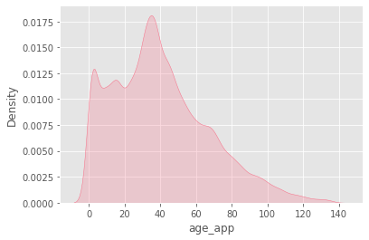

```python
# Distribution of the age
bold("Age of the application")
sns.kdeplot(data.age_app, shade=True)
plt.show()
```

```python
data.age_app.describe()
```

```
count    77108.000000
mean        40.118768
std         27.013121
min          0.030000
25%         19.590000
50%         36.560000
75%         56.280000
max        137.060000
Name: age_app, dtype: float64
```

we can observe that half of the mobile applications in the database have less than 4 years of seniority on the appstore. The distribution is slightly spread out on the right, in fact it is drawn by applications that are more than 10 years old on the appstore.

#### Release month

```python
def get_month(d1):
    """Return release month of application """
    return datetime.strptime(d1[:10], "%Y-%m-%d").strftime('%m-%b')
```

```python
data['releaseMonth'] = data.releaseDate.apply(get_month) # We add it to our dataframe
```

```python
# Distribution of the release month
aur = data['releaseMonth'].value_counts().sort_index()
p = figure(x_range=list(map(str, aur.index.values)),
           plot_height=300, title="Mois de sortie d'application",
           toolbar_location=None,
           tools="")

p.vbar(x=list(map(str, aur.index.values)),
       top=aur.values,
       width=0.8,
       color=Spectral9)

p.xgrid.grid_line_color = None
p.y_range.start = 0
show(p)
```

[interactive chart not shown]

#### Months since last update

```python
date_end="2019-12-10"
data['last_update'] = data.currentVersionReleaseDate.apply(lambda x : date_diff(x, date_end)) # We add it to our dataframe
```

**Visualization of the last update age**

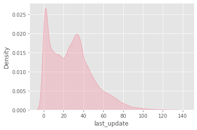

```python
#Visualization of the last update age
bold('Visualization of the last update age')
sns.kdeplot(data['last_update'], shade=True)
```

#### Number of languages

```python
data['nb_language'] = data.languageCodesISO2A.apply(len) # We add it to our dataframe
```

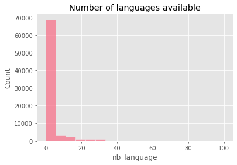

```python
#Visualization of the number of languages available in the app
fig = plt.figure(figsize=(6,4))
sns.histplot(data['nb_language'])
plt.title('Number of languages available')
plt.show()
```

#### Languages available

```python
# Search unique languages
def search_languages(data):
    unique_lang = []
    for list_lang in data.languageCodesISO2A:
        for lang in list_lang:
            if unique_lang.count(lang)==0:
                unique_lang.append(lang)
    return unique_lang


def dummy_langue(sub_liste,liste):
    '''Fonction qui crée autant de variables dummies qu'il y a de langues disponibles pour l'application

    Input:
        sub_liste: cellule qcq de la variable 'languageCodesISO2A'
        liste: liste des langues disponibles'''

    results=[]
    for elt in liste:
        y = (sub_liste.count(elt)!=0)*1 #élt est dans sous liste ?
        results.append(y)

    return results

def create_lang_df(data):
    unique_lang = search_languages(data)
    data_lang = data.languageCodesISO2A.apply(lambda x:dummy_langue(x, unique_lang))
    data_lang = data_lang.apply(pd.Series)
    data_lang = data_lang.rename(columns=dict(zip(range(132),unique_lang)))
    data_lang.index = data.id_app

    return data_lang

def search_languages_top(data_lang, nb):
    cum_lang = data_lang.sum(axis = 0).sort_values(ascending=False)
    top_lang = list(cum_lang[0:10].index)
    return top_lang
```

```python
data_lang = create_lang_df(data)
```

**Correlation entre les langues disponibles sur l'application**

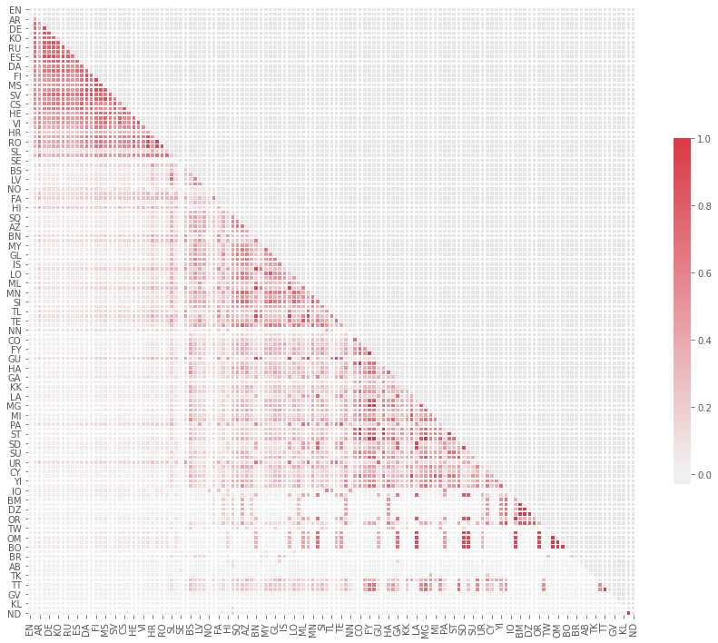

```python
#Correlation entre les différentes langues disponibles sur l'application
bold("Correlation entre les langues disponibles sur l'application")
corr = data_lang.corr()
mask = np.zeros_like(corr, dtype=np.bool)
mask[np.triu_indices_from(mask)] = True
f, ax = plt.subplots(figsize=(15, 14))
cmap = sns.diverging_palette(220, 10, as_cmap=True)
sns.heatmap(corr, mask=mask, cmap=cmap, vmax=1, center=0,square=True, linewidths=.5, cbar_kws={"shrink": .5})
```

```python
# We search the most used languages
nb = 10
top_lang = search_languages_top(data_lang, nb)
print("Top 10 Langues les plus présents hors anglais: ", top_lang)

print("{} % des applications proposes l'anglais comme langue".format(round(data_lang.EN.sum()/data_lang.shape[0]*100),2))
print("Elle n'est donc plus spécifique à certaines applications")
```

```
Top 10 Langues les plus présents hors anglais:  ['EN', 'ZH', 'FR', 'DE', 'JA', 'ES', 'RU', 'IT', 'PT', 'KO']
98 % des applications proposes l'anglais comme langue
Elle n'est donc plus spécifique à certaines applications
```

```python
data = data.merge(data_lang[top_lang], how='inner', left_on='id_app', right_index=True) # We add boolean columns for each of the top languages
```

#### Number of categories

```python
# We remove the main genre ("Games") since we only focus on games
data['genres'].apply(lambda s: s.remove('Games'))
```

```
86208    None
76485    None
29308    None
82931    None
82802    None
         ...
6265     None
54886    None
76820    None
860      None
15795    None
Name: genres, Length: 77108, dtype: object
```

```python
data['nb_genres'] = data.genres.apply(len) # We add it to our dataframe
```

```python
aur = data['nb_genres'].value_counts().sort_index()
p = figure(x_range=list(map(str, aur.index.values)),
           plot_height=300, title="Number of sub categories per application",
           toolbar_location=None,
           tools="")

p.vbar(x=list(map(str, aur.index.values)),
       top=aur.values,
       width=0.8,
       color=Spectral9)

p.xgrid.grid_line_color = None
p.y_range.start = 0
show(p)
```

[interactive chart not shown]

#### Categories

```python
def search_genres(data):
    unique_genre = []
    for list_genre in data.genres:
        for genre in list_genre:
            if unique_genre.count(genre)==0:
                unique_genre.append(genre)
    return unique_genre


def dummy_genre(sub_liste,liste):
    '''Fonction qui crée autant de variables dummies qu'il y a de genres
       pour l'application

    Input:
        sub_liste: cellule qcq de la variable 'Genres'
        liste: définition en extansion de la variable Genres'''

    results=[]
    for elt in liste:
        y = (sub_liste.count(elt)!=0)*1 #élt est dans sous liste ?
        results.append(y)

    return results

def create_genre_df(data):
    unique_genre = search_genres(data)
    data_genre = data.genres.apply(lambda x:dummy_genre(x, unique_genre))
    data_genre = data_genre.apply(pd.Series)
    data_genre = data_genre.rename(columns=dict(zip(range(len(unique_genre)),unique_genre)))
    data_genre.index = data.id_app

    return data_genre

def search_genres_top(data_genre, nb):
    cum_genres = data_genre.sum(axis = 0).sort_values(ascending=False)
    top_genre = list(cum_genres[:nb].index)
    return top_genre
```

```python
data_genre = create_genre_df(data)
```

**Correlation between the genres of the app**

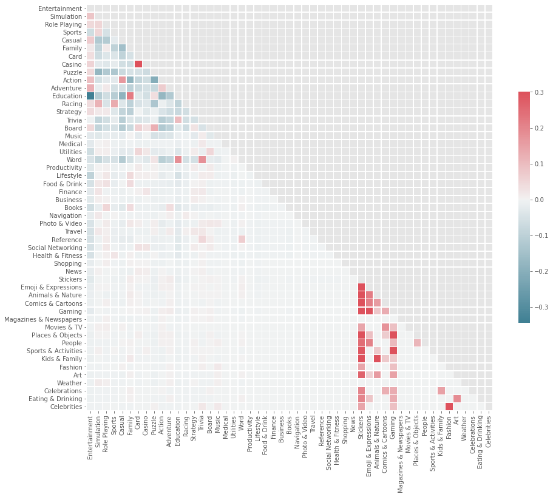

```python
# Correlation between the genres of the app
bold("Correlation between the genres of the app")
corr = data_genre.corr()
mask = np.zeros_like(corr, dtype=np.bool)
mask[np.triu_indices_from(mask)] = True
f, ax = plt.subplots(figsize=(15, 14))
cmap = sns.diverging_palette(220, 10, as_cmap=True)
sns.heatmap(corr, mask=mask, cmap=cmap, vmax=.3, center=0,square=True, linewidths=.5, cbar_kws={"shrink": .5})
```

```python
# We search the top genres
nb_genres = 20
top_genre = search_genres_top(data_genre, nb_genres)
print("Top 20 of the most present sub-categories: ", top_genre)
```

```
Top 20 of the most present sub-categories:  ['Entertainment', 'Puzzle', 'Casual', 'Family', 'Action', 'Education', 'Adventure', 'Simulation', 'Board', 'Strategy', 'Sports', 'Trivia', 'Role Playing', 'Racing', 'Word', 'Card', 'Music', 'Casino', 'Lifestyle', 'Utilities']
```

**Décroissance de l'occurence des genres**

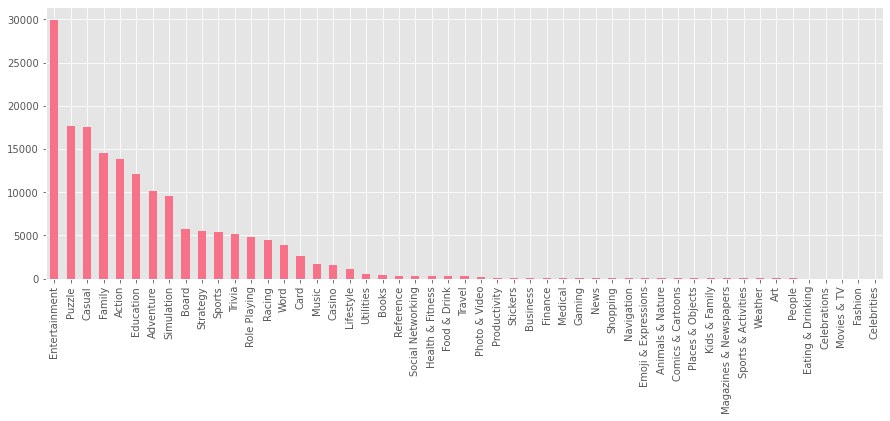

```python
bold("Décroissance de l'occurence des genres")
fig = plt.figure( figsize=(15,5))
cum_genres = data_genre.sum(axis = 0).sort_values(ascending=False)
cum_genres.plot(kind = 'bar')
```

```python
data = data.merge(data_genre[top_genre], how='inner', left_on='id_app', right_index=True) # We add it to the dataframe
```

#### Application size

```python
data.fileSizeBytes = pd.to_numeric(data.fileSizeBytes, errors='coerce')
# Convertion from kbytes to Mbytes
data['fileSizeMB']=data.fileSizeBytes.apply(lambda x : round(x/10**6,2))
```

**Size of the application in MB**

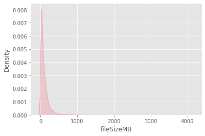

```python
bold("Size of the application in MB")
sns.kdeplot(data.fileSizeMB, shade=True)
```

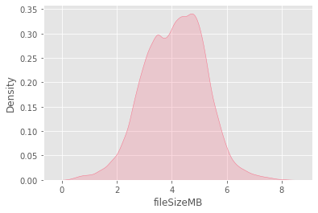

```python
sns.kdeplot(np.log(1+data.fileSizeMB), shade=True)
```

we can see that applaying the log function on the continuous features could help to equilibrate distribution.

#### Experience of the developper

```python
data_exp_dev = data[['sellerName','id_app']].groupby(by='sellerName', as_index=False).count()
```

**Experience of the developper**

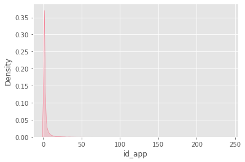

```python
bold('Experience of the developper')
sns.kdeplot(data_exp_dev.id_app, shade=True)
```

```python
data_exp_dev.rename(columns={'id_app':'Exp_dev'}, inplace = True)
data = data.merge(data_exp_dev, how='left', on='sellerName') # we add it
```

#### Corresponding function for the pipeline:

```python
def process_database(data):

    date_end ="2019-12-10" # The date from which the age is computed

    data['age_app'] = data.releaseDate.apply(lambda x : date_diff(x, date_end))
    data['releaseMonth'] = data.releaseDate.apply(get_month)
    data['last_update'] = data.currentVersionReleaseDate.apply(lambda x : date_diff(x, date_end))
    data['nb_language'] = data.languageCodesISO2A.apply(len)

    data_lang = create_lang_df(data)
    top_lang = search_languages_top(data_lang, nb=10) # num top languages = 10
    data = data.merge(data_lang[top_lang], how='inner', left_on='id_app', right_index=True) # Will need to return data[top_lang]

    data['genres'].apply(lambda s: s.remove('Games'))
    data['nb_genres'] = data.genres.apply(len)

    data_genre = create_genre_df(data)
    top_genre = search_genres_top(data_genre, nb=20) # num top genres = 20
    data = data.merge(data_genre[top_genre], how='inner', left_on='id_app', right_index=True) # Will need to return data[top_genre]

    data.fileSizeBytes = pd.to_numeric(data.fileSizeBytes, errors='coerce')
    data['fileSizeMB']=data.fileSizeBytes.apply(lambda x : round(x/10**6,2))

    data_exp_dev = data[['sellerName','id_app']].groupby(by='sellerName', as_index=False).count()
    data_exp_dev.rename(columns={'id_app':'Exp_dev'}, inplace = True)
    data = data.merge(data_exp_dev, how='left', on='sellerName') # Will need to return data['Exp_dev']

    return np.c_[data['age_app'].values,
                 data['releaseMonth'].values,
                 data['last_update'].values,
                 data['nb_language'].values,
                 data[top_lang].values,
                 data['nb_genres'].values,
                 data[top_genre].values,
                 data['fileSizeMB'].values,
                 data['Exp_dev'].values]
```

```python
def date_diff(d1, d2):
    """Returns the difference between two dates in months"""
    d1 = datetime.strptime(d1[:10], "%Y-%m-%d")
    d2 = datetime.strptime(d2, "%Y-%m-%d")
    return round(abs((d2 - d1)).days*(12/365),2)

def get_month(d1):
    """Return release month of application """
    return datetime.strptime(d1[:10], "%Y-%m-%d").strftime('%m-%b')

def search_languages(data):
    unique_lang = []
    for list_lang in data.languageCodesISO2A:
        for lang in list_lang:
            if unique_lang.count(lang)==0:
                unique_lang.append(lang)
    return unique_lang


def dummy_langue(sub_liste,liste):
    '''Fonction qui crée autant de variables dummies qu'il y a de langues disponibles pour l'application

    Input:
        sub_liste: cellule qcq de la variable 'languageCodesISO2A'
        liste: liste des langues disponibles'''

    results=[]
    for elt in liste:
        y = (sub_liste.count(elt)!=0)*1 #élt est dans sous liste ?
        results.append(y)

    return results

def create_lang_df(data):
    unique_lang = search_languages(data)
    data_lang = data.languageCodesISO2A.apply(lambda x:dummy_langue(x, unique_lang))
    data_lang = data_lang.apply(pd.Series)
    data_lang = data_lang.rename(columns=dict(zip(range(132),unique_lang)))
    data_lang.index = data.id_app

    return data_lang

def search_languages_top(data_lang, nb):
    cum_lang = data_lang.sum(axis = 0).sort_values(ascending=False)
    top_lang = list(cum_lang[0:10].index)
    return top_lang

def search_genres(data):
    unique_genre = []
    for list_genre in data.genres:
        for genre in list_genre:
            if unique_genre.count(genre)==0:
                unique_genre.append(genre)
    return unique_genre


def dummy_genre(sub_liste,liste):
    '''Fonction qui crée autant de variables dummies qu'il y a de genres
       pour l'application

    Input:
        sub_liste: cellule qcq de la variable 'Genres'
        liste: définition en extansion de la variable Genres'''

    results=[]
    for elt in liste:
        y = (sub_liste.count(elt)!=0)*1 #élt est dans sous liste ?
        results.append(y)

    return results

def create_genre_df(data):
    unique_genre = search_genres(data)
    data_genre = data.genres.apply(lambda x:dummy_genre(x, unique_genre))
    data_genre = data_genre.apply(pd.Series)
    data_genre = data_genre.rename(columns=dict(zip(range(len(unique_genre)),unique_genre)))
    data_genre.index = data.id_app

    return data_genre

def search_genres_top(data_genre, nb):
    cum_genres = data_genre.sum(axis = 0).sort_values(ascending=False)
    top_genre = list(cum_genres[:nb].index)
    return top_genre
```

### Target visualization

**Success of the application**

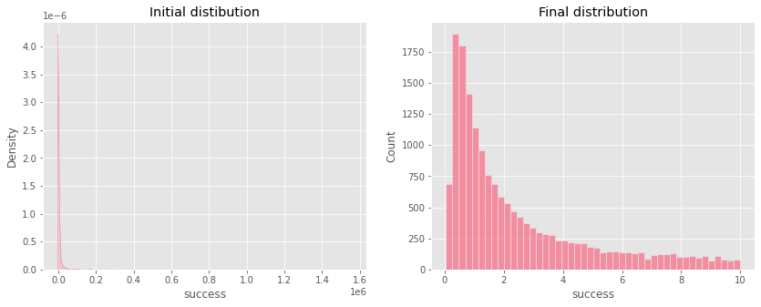

```python
bold("Success of the application")
fig, axs = plt.subplots(nrows=1, ncols=2, figsize = (7*2, 5))
sns.kdeplot(data.success, shade=True, ax=axs[0])
axs[0].set_title('Initial distibution')
thresh = 10
sns.histplot(data[(data.success<thresh) & (data.success>0)]['success'], ax=axs[1])
axs[1].set_title('Final distribution')
plt.show()
```

```python
print("There are only a few apps. with a none zero success score:", data[(data.success>0)]['success'].shape[0])
print("This represents a small percentage of :  {:.3%}".format(data[(data.success>0)]['success'].shape[0] / data.shape[0]))
```

```
There are only a few apps. with a none zero success score: 26140
This represents a small percentage of :  33.901%
```

In order to simplify training, we can chose to get rid of the applications with a score of 0. Indeed, those applications were never downloaded or rated. One issue that would occur by keeping them is that they have a success score quite close from the apps. with a low "total" success score, but which are quite old.

```python
data = data.drop(data[data.success == 0].index)
```

```python
data.head(3)
```

|  | id_app | releaseDate | artworkUrl512 | languageCodesISO2A | fileSizeBytes | minimumOsVersion | trackName | contentAdvisoryRating | genres | sellerName | ... | Role Playing | Racing | Word | Card | Music | Casino | Lifestyle | Utilities | fileSizeMB | Exp_dev |
| --- | --- | --- | --- | --- | --- | --- | --- | --- | --- | --- | --- | --- | --- | --- | --- | --- | --- | --- | --- | --- | --- |
| 0 | 1198939406 | 2017-02-24T17:02:13Z | https://is2-ssl.mzstatic.com/image/thumb/Purpl... | [EN] | 134074368.0 | 7.0 | Tourist Transport Ship - Cruise Boat Simulator | 1 | [Entertainment, Simulation, Role Playing] | Khurram Fazal | ... | 1 | 0 | 0 | 0 | 0 | 0 | 0 | 0 | 134.07 | 16 |
| 7 | 1191037021 | 2017-09-06T19:33:13Z | https://is1-ssl.mzstatic.com/image/thumb/Purpl... | [EN] | 773610496.0 | 9.0 | Forward Assault | 4 | [Action, Adventure] | Blayze Games, L.L.C. | ... | 0 | 0 | 0 | 0 | 0 | 0 | 0 | 0 | 773.61 | 2 |
| 8 | 1066800102 | 2015-12-16T23:07:58Z | https://is1-ssl.mzstatic.com/image/thumb/Purpl... | [EN] | 33815552.0 | 8.0 | Hot Potato - Board Game | 1 | [Entertainment] | Appchance | ... | 0 | 0 | 0 | 0 | 0 | 0 | 0 | 0 | 33.82 | 1 |

3 rows × 54 columns

### Data Visualization

Here are a few plots which can give a first idea of the relationship between the success score and some variables. As a side note, it should give you some ideas of which feature engineering tasks should be implemented (by yourself).

```python
data.columns
```

```
Index(['id_app', 'releaseDate', 'artworkUrl512', 'languageCodesISO2A',
       'fileSizeBytes', 'minimumOsVersion', 'trackName',
       'contentAdvisoryRating', 'genres', 'sellerName', 'formattedPrice',
       'price', 'currency', 'version', 'description',
       'currentVersionReleaseDate', 'age_app', 'success', 'releaseMonth',
       'last_update', 'nb_language', 'EN', 'ZH', 'FR', 'DE', 'JA', 'ES', 'RU',
       'IT', 'PT', 'KO', 'nb_genres', 'Entertainment', 'Puzzle', 'Casual',
       'Family', 'Action', 'Education', 'Adventure', 'Simulation', 'Board',
       'Strategy', 'Sports', 'Trivia', 'Role Playing', 'Racing', 'Word',
       'Card', 'Music', 'Casino', 'Lifestyle', 'Utilities', 'fileSizeMB',
       'Exp_dev'],
      dtype='object')
```

```python
var_quant = [ 'fileSizeMB', 'contentAdvisoryRating', 'price', 'age_app'
            , 'last_update', 'nb_language', 'nb_genres', 'Exp_dev']
```

**Dependence between features and target variable**

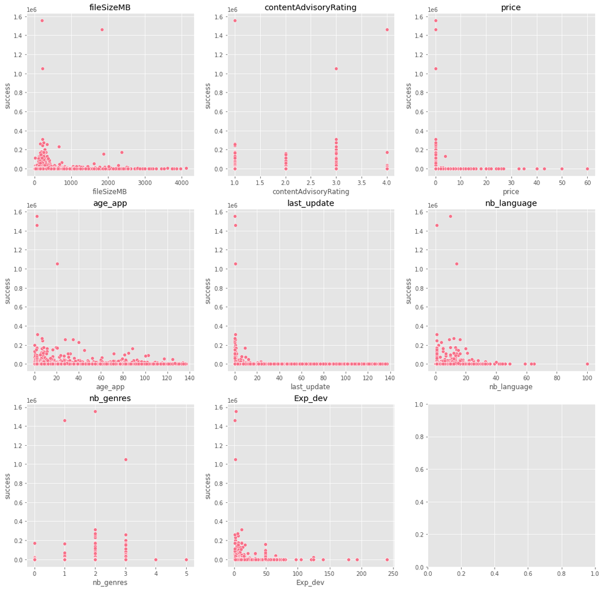

```python
bold("Dependence between features and target variable")
ncols = 3
nrows = len(var_quant) // ncols + (len(var_quant) % ncols != 0 )*1

fig, axs = plt.subplots(nrows=nrows, ncols=ncols, figsize = (6 * ncols, 6*nrows))

for i, col in enumerate(var_quant):
    l =  i // ncols
    k = i - ncols  * l
    sns.scatterplot(x=data[col], y=data['success'], ax=axs[l][k])
    axs[l][k].set_title(col)
```

**Dependence between transformed features and transformed target**

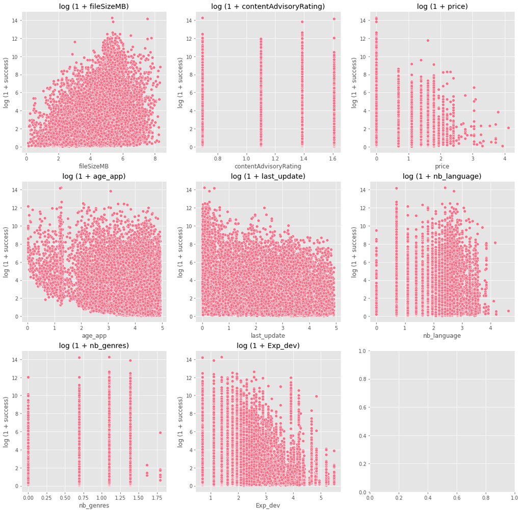

```python
bold("Dependence between transformed features and transformed target")
ncols = 3
nrows = len(var_quant) // ncols + (len(var_quant) % ncols != 0 )*1

fig, axs = plt.subplots(nrows=nrows, ncols=ncols, figsize = (6 * ncols, 6*nrows))

for i, col in enumerate(var_quant):
    l =  i // ncols
    k = i - ncols  * l
    sns.scatterplot(x=np.log(1+data[col]), y=np.log(1+data['success']), ax=axs[l][k])
    axs[l][k].set_title('log (1 + {})'.format(col))
    axs[l][k].set_ylabel('log (1 + success)')
```

The log transformation of the features and the target makes it possible to reduce the skewness of the variables by giving less importance to the typical values of the variables which are very far by the right. This transformation then makes it possible to better appreciate the dependency between the covariates and the target. It can be pointed out that :

- The most expensive applications are not necessarily the most successful on the appstore. Indeed, success seems to decrease when the price of the application is high.
- A positive dependency between application success and size is observed, although for the heaviest applications, the relationship is less stable than for the smallest applications.

### Correlation between variables

```python
keep_var = [ 'success', 'contentAdvisoryRating','price', 'age_app', 'releaseMonth',
       'last_update', 'nb_language', 'EN', 'ZH', 'FR', 'DE', 'JA', 'ES', 'RU',
       'IT', 'PT', 'KO', 'nb_genres', 'Entertainment', 'Puzzle', 'Casual',
       'Family', 'Action', 'Education', 'Adventure', 'Simulation', 'Board',
       'Strategy', 'Sports', 'Trivia', 'Role Playing', 'Racing', 'Word',
       'Card', 'Music', 'Casino', 'Lifestyle', 'Utilities', 'fileSizeMB', 'Exp_dev']
```

**Anlaysis of correlations via heatmap**

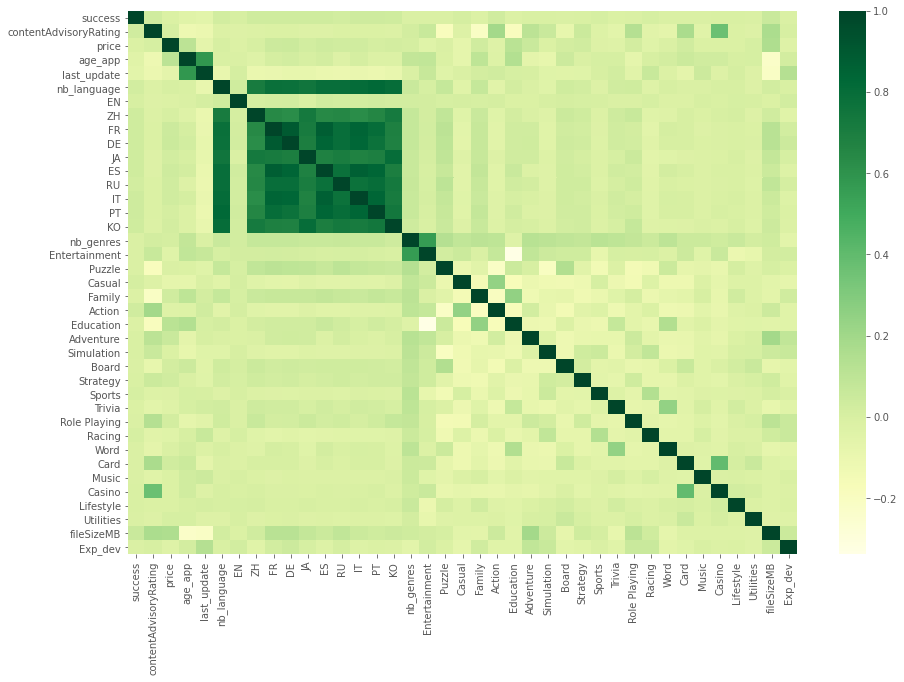

```python
bold('Anlaysis of correlations via heatmap')
plt.figure(figsize=(15, 10))
sns.heatmap(data[keep_var].corr(), cmap='YlGn')
#plt.title('Anlaysis of correlations via heatmap');
```

## Workflow

```python
import os

import pandas as pd
import numpy as np
from datetime import datetime

from sklearn.preprocessing import FunctionTransformer
from sklearn.compose import ColumnTransformer
from sklearn.pipeline import Pipeline, make_pipeline

from sklearn.ensemble import RandomForestRegressor
from sklearn.metrics import make_scorer, mean_squared_error
from sklearn.model_selection import cross_val_score
from sklearn.model_selection import ShuffleSplit

from problem import _read_data
```

```python
#Read data

data = pd.read_json('./data/train.json')
data = data.drop(data[data.success == 0].index)

y = data['success'].values
y = np.log(y + 1)

data = data.drop("success", axis=1)
```

```python
def contentAdvisoryRating_recode(val):
    if val=='4_plus':
        output = 1
    elif val == '9_plus':
        output = 2
    elif val == '12_plus':
        output = 3
    else:
        output = 4
    return output

def date_diff(d1, d2):
    """Returns the difference between two dates in months"""
    d1 = datetime.strptime(d1[:10], "%Y-%m-%d")
    d2 = datetime.strptime(d2, "%Y-%m-%d")
    return round(abs((d2 - d1)).days*(12/365),2)

def get_month(d1):
    """Return release month of application """
    return datetime.strptime(d1[:10], "%Y-%m-%d").strftime('%m-%b')

def search_languages(data):
    unique_lang = []
    for list_lang in data.languageCodesISO2A:
        for lang in list_lang:
            if unique_lang.count(lang)==0:
                unique_lang.append(lang)
    return unique_lang


def dummy_langue(sub_liste,liste):
    '''Fonction qui crée autant de variables dummies qu'il y a de langues disponibles pour l'application

    Input:
        sub_liste: cellule qcq de la variable 'languageCodesISO2A'
        liste: liste des langues disponibles'''

    results=[]
    for elt in liste:
        y = (sub_liste.count(elt)!=0)*1 #élt est dans sous liste ?
        results.append(y)

    return results

def create_lang_df(data):
    unique_lang = search_languages(data)
    data_lang = data.languageCodesISO2A.apply(lambda x:dummy_langue(x, unique_lang))
    data_lang = data_lang.apply(pd.Series)
    data_lang = data_lang.rename(columns=dict(zip(range(132),unique_lang)))
    data_lang.index = data.id_app

    return data_lang

def search_languages_top(data_lang, nb):
    cum_lang = data_lang.sum(axis = 0).sort_values(ascending=False)
    top_lang = list(cum_lang[0:10].index)
    return top_lang

def search_genres(data):
    unique_genre = []
    for list_genre in data.genres:
        for genre in list_genre:
            if unique_genre.count(genre)==0:
                unique_genre.append(genre)
    return unique_genre


def dummy_genre(sub_liste,liste):
    '''Fonction qui crée autant de variables dummies qu'il y a de genres
       pour l'application

    Input:
        sub_liste: cellule qcq de la variable 'Genres'
        liste: définition en extansion de la variable Genres'''

    results=[]
    for elt in liste:
        y = (sub_liste.count(elt)!=0)*1 #élt est dans sous liste ?
        results.append(y)

    return results

def create_genre_df(data):
    unique_genre = search_genres(data)
    data_genre = data.genres.apply(lambda x:dummy_genre(x, unique_genre))
    data_genre = data_genre.apply(pd.Series)
    data_genre = data_genre.rename(columns=dict(zip(range(len(unique_genre)),unique_genre)))
    data_genre.index = data.id_app

    return data_genre

def search_genres_top(data_genre, nb):
    cum_genres = data_genre.sum(axis = 0).sort_values(ascending=False)
    top_genre = list(cum_genres[:nb].index)
    return top_genre
```

```python
def process_database(data):

    data['contentAdvisoryRating'] = data['contentAdvisoryRating'].apply(lambda x : x.replace('+', '_plus'))
    data['contentAdvisoryRating'] = data['contentAdvisoryRating'].apply(contentAdvisoryRating_recode)

    data.price = pd.to_numeric(data.price, errors='coerce')

    date_end ="2019-12-10" # The date from which the age is computed

    data['age_app'] = data.releaseDate.apply(lambda x : date_diff(x, date_end))
    data['releaseMonth'] = data.releaseDate.apply(get_month)
    data['last_update'] = data.currentVersionReleaseDate.apply(lambda x : date_diff(x, date_end))
    data['nb_language'] = data.languageCodesISO2A.apply(len)

    data_lang = create_lang_df(data)
    top_lang = search_languages_top(data_lang, nb=10) # num top languages = 10
    data = data.merge(data_lang[top_lang], how='inner', left_on='id_app', right_index=True) # Will need to return data[top_lang]

    #data['genres'].apply(lambda s: s.remove('Games'))
    data['nb_genres'] = data.genres.apply(len)

    data_genre = create_genre_df(data)
    top_genre = search_genres_top(data_genre, nb=20) # num top genres = 20
    data = data.merge(data_genre[top_genre], how='inner', left_on='id_app', right_index=True) # Will need to return data[top_genre]

    sizes = pd.to_numeric(data.fileSizeBytes, errors='coerce')
    sizes = sizes.fillna(0)
    data['fileSizeMB']=sizes.apply(lambda x : np.log(round(x/10**6,2)+1))

    data_exp_dev = data[['sellerName','id_app']].groupby(by='sellerName', as_index=False).count()
    data_exp_dev.rename(columns={'id_app':'Exp_dev'}, inplace = True)
    data = data.merge(data_exp_dev, how='left', on='sellerName') # Will need to return data['Exp_dev']

    return np.c_[np.log( 1 + data['age_app'].values),
                 pd.get_dummies(data[['releaseMonth']]).values,
                 np.log(1 + data['last_update'].values),
                 np.log(1 + data['nb_language'].values),
                 data[top_lang].values,
                 data['nb_genres'].values,
                 data[top_genre].values,
                 np.log( 1 + data['fileSizeMB'].values),
                 np.log( 1 + data['Exp_dev'].values)]
```

```python
from sklearn.preprocessing import FunctionTransformer, OneHotEncoder, StandardScaler
from sklearn.compose import ColumnTransformer
from sklearn.pipeline import Pipeline, make_pipeline

all_col = ['id_app', 'releaseDate', 'artworkUrl512', 'languageCodesISO2A',
       'fileSizeBytes', 'minimumOsVersion', 'trackName',
       'contentAdvisoryRating', 'genres', 'sellerName', 'formattedPrice',
       'price', 'currency', 'version', 'description',
       'currentVersionReleaseDate', 'age_app']

drop = ['releaseDate', 'artworkUrl512', 'languageCodesISO2A', 'fileSizeBytes',
        'trackName', 'genres', 'sellerName', 'formattedPrice', 'currency',
        'description', 'currentVersionReleaseDate']

database_transformer = FunctionTransformer(
        process_database, validate=False
    )

preprocessor = ColumnTransformer(
        transformers=[
            ('new_vars_process', database_transformer, all_col),
            ('drop cols', 'drop', drop),
        ], remainder='passthrough', n_jobs=-1)
```

```python
preprocessor.fit_transform(data)
```

```
array([[3.54095932, 0.        , 1.        , ..., 0.        , 1.77593376,
        2.07944154],
       [3.33648107, 0.        , 0.        , ..., 0.        , 2.03501405,
        1.09861229],
       [3.88854965, 0.        , 0.        , ..., 0.        , 1.51516942,
        0.69314718],
       ...,
       [3.79458991, 0.        , 0.        , ..., 0.        , 1.65668443,
        1.60943791],
       [3.60114054, 0.        , 0.        , ..., 0.        , 1.50551146,
        1.09861229],
       [2.87016905, 0.        , 0.        , ..., 0.        , 1.80562323,
        1.60943791]])
```

```python
from sklearn.ensemble import RandomForestRegressor
from sklearn.metrics import mean_squared_error
from sklearn.model_selection import cross_val_score
from sklearn.model_selection import ShuffleSplit

regressor = RandomForestRegressor(n_estimators=50, max_depth=20, max_features=.8, n_jobs=-1 )
```

```python
clf = Pipeline(steps=[
    ('preprocessing', preprocessor),
    ('classifier', regressor)])

cv = ShuffleSplit(n_splits=5, test_size=0.20)

scores_Xdf = cross_val_score(clf, data, y, cv=cv, scoring='mean_squared_error')
```

```python
print("mse: %.2e (+/- %.2e)" % (scores_Xdf.mean(), scores_Xdf.std()))
print("rmse: %.2e" % np.sqrt(scores_Xdf.mean()))
```

```
mse: 2.81e+00 (+/- 7.66e-02)
rmse: 1.68e+00
```

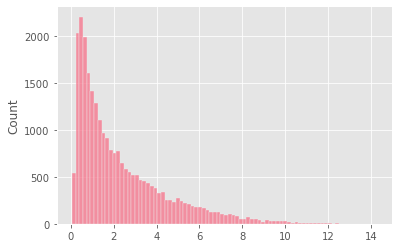

```python
_ = sns.histplot(y)
```

```python
rmse = np.sqrt(scores_Xdf.mean())
std = np.std(y)
print("Standard deviation of y : {:.5}".format(std))
print("Model validation rmse: {:.5}".format(rmse))
print("Standardise RSME {:.2f}".format(rmse/std))
```

```
Standard deviation of y : 2.1177
Model validation rmse: 1.6762
Standardise RSME 0.79
```

The random forest trained here yields to an rsme of 1.67 for and output that goes from 0 to 14. Moreover, the standardize RSME on the validation set is less than 100 %, the model perform better than the benchmark model in which $\hat{y}$ is predicted by the mean value of y in the train set. But we are sure that you perform much much better :). Break a leg!!

## Conclusion

The objective of this challenge is to predict the success of an application in a way that we have chosen here by observing the available features. It is therefore not an absolute metric to measure the success of an application, however we think it's a wise choice.

As far as the database is concerned, especially its improvement, there is some available features on the App Store that we did not take into account and that could have provided more information to determine the success of an application.

For instance, the images available on the application's description page (its logo and those presenting its content), which would imply a learning of features with a convolutional network on it. We also have the number of comments and their content which should be full of a lot of information that is correlated to the application's rating and therefore to its success. Indeed, a sentiment analysis carried out on these comments would allow a prediction of the score, for example. The difficulty here is that many applications do not have comments. However, this missing data could provide information on success in the sense that we could consider the absence of comments to be linked to a low download rate for example. Another textual data that we could consider is the description of each application, some keywords could promote the success of an application in the sense that we have defined it.

## Example of submission

```python
import os

import pandas as pd
import numpy as np
from datetime import datetime

from sklearn.preprocessing import FunctionTransformer
from sklearn.compose import ColumnTransformer
from sklearn.pipeline import Pipeline, make_pipeline

from sklearn.ensemble import RandomForestRegressor
from sklearn.metrics import make_scorer, mean_squared_error
from sklearn.model_selection import cross_val_score
from sklearn.model_selection import ShuffleSplit



def contentAdvisoryRating_recode(val):
    if val == '4_plus':
        output = 1
    elif val == '9_plus':
        output = 2
    elif val == '12_plus':
        output = 3
    else:
        output = 4
    return output

def date_diff(d1, d2):
    """Returns the difference between two dates in months"""
    d1 = datetime.strptime(d1[:10], "%Y-%m-%d")
    d2 = datetime.strptime(d2, "%Y-%m-%d")
    return round(abs((d2 - d1)).days*(12/365),2)

def get_month(d1):
    """Return release month of application """
    return datetime.strptime(d1[:10], "%Y-%m-%d").strftime('%m-%b')

def search_languages(data):
    unique_lang = []
    for list_lang in data.languageCodesISO2A:
        for lang in list_lang:
            if unique_lang.count(lang)==0:
                unique_lang.append(lang)
    return unique_lang

def dummy_langue(sub_liste,liste):
    '''Function that creates as many dummy variables as there are languages available for the application.

    Input:
        sub_liste: list of languages availaible for the application i-e
                   a cell of the column 'languageCodesISO2A'
        liste: list of availaible languages'''

    results=[]
    for elt in liste:
        y = ( sub_liste.count(elt) != 0 ) * 1 # test if the current elt is in the  subliste
        results.append(y)

    return results

def create_lang_df(data):
    unique_lang = search_languages(data)
    data_lang = data.languageCodesISO2A.apply(lambda x:dummy_langue(x, unique_lang))
    data_lang = data_lang.apply(pd.Series)
    data_lang = data_lang.rename(columns=dict(zip(range(132),unique_lang)))
    data_lang.index = data.id_app

    return data_lang

def search_languages_top(data_lang, nb):
    cum_lang = data_lang.sum(axis=0).sort_values(ascending=False)
    top_lang = list(cum_lang[0:10].index)
    return top_lang

def search_genres(data):
    unique_genre = []
    for list_genre in data.genres:
        for genre in list_genre:
            if unique_genre.count(genre)==0:
                unique_genre.append(genre)
    return unique_genre

def dummy_genre(sub_liste,liste):
    '''Function that creates as many dummy genre as there are genre available for the application.


    Input:
        sub_liste: all the genres of one application,
                   a a cell of the column 'Genres'
        liste: extended definition of the variable Genres'''

    results=[]
    for elt in liste:
        y = (sub_liste.count(elt)!=0)*1 # test if the current elt is in the  subliste
        results.append(y)

    return results

def create_genre_df(data):
    unique_genre = search_genres(data)
    data_genre = data.genres.apply(lambda x:dummy_genre(x, unique_genre))
    data_genre = data_genre.apply(pd.Series)
    data_genre = data_genre.rename(columns=dict(zip(range(len(unique_genre)),unique_genre)))
    data_genre.index = data.id_app

    return data_genre

def search_genres_top(data_genre, nb):
    cum_genres = data_genre.sum(axis = 0).sort_values(ascending=False)
    top_genre = list(cum_genres[:nb].index)
    return top_genre


def process_database(data):

    data['contentAdvisoryRating'] = data['contentAdvisoryRating'].apply(lambda x : x.replace('+', '_plus'))
    data['contentAdvisoryRating'] = data['contentAdvisoryRating'].apply(contentAdvisoryRating_recode)

    data.price = pd.to_numeric(data.price, errors='coerce')

    date_end ="2019-12-10" # The date from which the age is computed

    data['age_app'] = data.releaseDate.apply(lambda x : date_diff(x, date_end))
    data['releaseMonth'] = data.releaseDate.apply(get_month)
    data['last_update'] = data.currentVersionReleaseDate.apply(lambda x : date_diff(x, date_end))
    data['nb_language'] = data.languageCodesISO2A.apply(len)

    data_lang = create_lang_df(data)
    top_lang = search_languages_top(data_lang, nb=10) # num top languages = 10
    data = data.merge(data_lang[top_lang], how='inner', left_on='id_app', right_index=True) # Will need to return data[top_lang]

    data['nb_genres'] = data.genres.apply(len)

    data_genre = create_genre_df(data)
    top_genre = search_genres_top(data_genre, nb=20) # num top genres = 20
    data = data.merge(data_genre[top_genre], how='inner', left_on='id_app', right_index=True) # Will need to return data[top_genre]

    sizes = pd.to_numeric(data.fileSizeBytes, errors='coerce')
    sizes = sizes.fillna(0)
    data['fileSizeMB']=sizes.apply(lambda x : np.log(round(x/10**6,2)+1))

    data_exp_dev = data[['sellerName','id_app']].groupby(by='sellerName', as_index=False).count()
    data_exp_dev.rename(columns={'id_app':'Exp_dev'}, inplace = True)
    data = data.merge(data_exp_dev, how='left', on='sellerName') # Will need to return data['Exp_dev']

    return np.c_[np.log( 1 + data['age_app'].values),
                 pd.get_dummies(data[['releaseMonth']]).values,
                 np.log(1 + data['last_update'].values),
                 np.log(1 + data['nb_language'].values),
                 data[top_lang].values,
                 data['nb_genres'].values,
                 data[top_genre].values,
                 np.log( 1 + data['fileSizeMB'].values),
                 np.log( 1 + data['Exp_dev'].values)]




def get_estimator():

    all_col = ['id_app', 'releaseDate', 'artworkUrl512', 'languageCodesISO2A',
       'fileSizeBytes', 'minimumOsVersion', 'trackName',
       'contentAdvisoryRating', 'genres', 'sellerName', 'formattedPrice',
       'price', 'currency', 'version', 'description',
       'currentVersionReleaseDate', 'age_app']

    drop = ['releaseDate', 'artworkUrl512', 'languageCodesISO2A', 'fileSizeBytes',
        'trackName', 'genres', 'sellerName', 'formattedPrice', 'currency',
        'description', 'currentVersionReleaseDate']

    database_transformer = FunctionTransformer(
        process_database, validate=False
    )

    preprocessor = ColumnTransformer(
        transformers=[
            ('new_vars_and_process', database_transformer, all_col),
            ('drop cols', 'drop', drop),
        ], remainder='passthrough', n_jobs=-1)

    regressor = RandomForestRegressor(
            n_estimators=50, max_depth=20, max_features=.8, n_jobs=-1
        )

    pipeline = Pipeline(steps=[
        ('preprocessing', preprocessor),
        ('classifier', regressor)
    ])

    return pipeline
```

How to test and submit your solution .

- Make sure you have installed ramp-workflow locally (see above)
- Make sure that the python file estimator.py is in submissions/, and the train and test data are in data
- If you haven't yet, download the data by executing python download_data.py
- Finally, make sure the local processing goes through by running the

ramp-test --submission

If you want to quickly test the that there are no obvious code errors, use the --quick-test flag to only use a small subset of the data (training and testing sets with 5 elements each).

ramp-test --submission --quick-test

You can refer to the [online documentation](https://paris-saclay-cds.github.io/ramp-docs/ramp-workflow/stable/using_kits.html#test-a-submission).

## Annexe

Here, we added the code which allowed us to build the database. For instance, it shows the computation of the success score, the deletion of some columns, or the slipt between train and test set.

```python
run = False
if run :
    df = pd.concat(map(pd.read_json, glob.glob(os.path.join('./Base_scraped', "plage*.json"))))

    print('Le jeux de données comporte {} doublons'.format(df.shape[0]-df.id_app.nunique()))
    print('Nb unique = {}'.format(df.id_app.nunique()))

    data = df.drop_duplicates(subset="id_app", keep='first' )
    data.reset_index(drop=True, inplace=True)
    del df
    data.shape

    def date_diff(d1, d2):
        """Return difference between two dates in months"""
        d1 = datetime.strptime(d1[:10], "%Y-%m-%d")
        d2 = datetime.strptime(d2, "%Y-%m-%d")
        return round(abs((d2 - d1)).days * (12 / 365), 2)

    date_end ="2019-12-10"
    data['old_app'] = data.releaseDate.apply(lambda x : date_diff(x, date_end))

    def change_to_zero(y):
        if y == '':
            y = 0.0
        return y

    data['averageUserRating'] = data['averageUserRating'].apply(change_to_zero)
    data['userRatingCount'] = data['userRatingCount'].apply(change_to_zero)
    data.head()

    fig, ax = plt.subplots(nrows=1, ncols=2, figsize=(12, 5))
    sns.histplot(data[data.userRatingCount < 2e2], ax=ax[0])
    ax[0].set_xlabel('Average User Rating')
    sns.histplot(data[data.userRatingCount < 2e2], x="userRatingCount", bins=50, ax=ax[1])
    ax[1].set_xlabel('user Rating Count')
    plt.plot()
    plt.savefig('rating_count.png')

    data.loc[(data.age_app == 0),'age_app'] = 1/31

    success = (data['averageUserRating'] * data['userRatingCount']) / data['age_app']
    data['success'] = success

    data = data.drop(columns=['averageUserRatingForCurrentVersion', 'userRatingCountForCurrentVersion', 'averageUserRating', 'userRatingCount'])

    from sklearn.model_selection import train_test_split
    train, test = train_test_split(data, test_size=0.2, random_state=42, shuffle=True)

    train.to_json(r'.\train.json')
    test.to_json(r'.\test.json')
```